# UC00198_Waste_Management_And_Health_Risks

UC00198_Waste_Management_And_Health_Risks

Author: Deepthi Reddy Thatipally

Level: Intermediate

Skills: Python, Data Visualisation

## Scenario

The City of Melbourne generates large amounts of waste every month. This waste is collected from different zones and managed through public services. However, when waste collection is delayed or poorly managed, it can lead to problems like bad smells, pests, pollution, and even health issues for people living nearby. As a data analyst, I want to explore whether there is a connection between the amount of waste collected, the public complaints about waste issues, and the health and wellbeing of residents. I will use data from the city’s open data portal to investigate if some zones are more affected than others and whether better waste management could improve community wellbeing.

## What this Use Case will teach you

By working on this use case, you will learn:

- import, clean, and merge multiple real-world datasets from an API
- to use location-based and time-based data to uncover patterns
- to link operational data (waste collection) with social data (health and complaints)
- to use basic data analysis and visualisation techniques to support decision-making
- Ito identify areas that may need improved services or health interventions

## Background/ Introduction

Waste management is a key part of keeping cities clean, healthy, and liveable. Poorly managed waste can lead to pollution, spread of disease, and lower quality of life. In Melbourne, different zones are responsible for collecting and managing waste. At the same time, the city collects feedback from residents through customer service complaints and regularly surveys them about their wellbeing.

This project aims to connect the dots between:

- How much waste is being collected,
- Where that waste is coming from,
- What residents are saying about waste issues,
- And how people are feeling in terms of health and wellbeing.

```python
import requests
import pandas as pd
from io import StringIO

def API_upload(dataset_id):
    core_url = 'https://data.melbourne.vic.gov.au/api/explore/v2.1/catalog/datasets/'
    file_format = 'csv'

    web_url = f'{core_url}{dataset_id}/exports/{file_format}'

    params = {
        'select': '*',
        'timezone': 'UTC',
        'lang': 'en',
        'limit': '-1'
    }

    response = requests.get(web_url, params=params)

    if response.status_code == 200:
        csv_content = response.content.decode('utf-8')
        try:
            df_dataset = pd.read_csv(StringIO(csv_content), delimiter=';')
        except Exception:
            print("Semicolon delimiter failed, trying comma delimiter.")
            df_dataset = pd.read_csv(StringIO(csv_content))

        print(f"\nDataset: {dataset_id}\n")
        print(df_dataset.head())
        print(f"\nTotal records: {len(df_dataset)}")
        return df_dataset
    else:
        print(f"Error fetching data from {web_url}: {response.status_code}")
        return None

# Load each dataset
df_social = API_upload('social-indicators-for-city-of-melbourne-residents-2023')
df_waste = API_upload('waste-collected-per-month')
df_zones = API_upload('garbage-collection-zones')
df_complaints = API_upload('customer-service-requests-with-resolution-time')
```

```
Dataset: social-indicators-for-city-of-melbourne-residents-2023

  indicator                    type                         topic  \
0        19                   Other                        Health
1        19                   Other                        Health
2        19                   Other                        Health
3         1  Council Plan Indicator             Physical activity
4       12b  Council Plan Indicator  Arts and cultural activities

                                         description  \
0                                   Vaping behaviour
1                                   Vaping behaviour
2                                   Vaping behaviour
3          Participate in adequate physical activity
4  Participate in arts and cultural activities in...

                                            response  \
0       Reported as vape daliy or vape occassionally
1       Reported as vape daliy or vape occassionally
2       Reported as vape daliy or vape occassionally
3  Yes, 30 minutes or more on 4 or more days per ...
4                          Yes, in the last 3 months

                                  respondent_group  year  sample_size  result  \
0                              East Melbourne 3002  2023           69     5.0
1                                   Parkville 3052  2023           77    17.6
2  South Yarra 3141 / Melbourne/St Kilda Road 3004  2023          137     8.4
3                                      25-34 years  2023          385    45.1
4                                      55-64 years  2023          115    12.6

     format
0  Per cent
1  Per cent
2  Per cent
3  Per cent
4  Per cent

Total records: 594

Dataset: waste-collected-per-month
```

[output cut: 114 more lines]

```
                            category                   service_desc  \
0  Waste, Street Cleaning and Litter       Syringe pick-up services
1                  Roads and Traffic  Road and Footpath Maintenance
2  Waste, Street Cleaning and Litter      Waste collection services
3                           Graffiti               Graffiti Removal
4  Waste, Street Cleaning and Litter       Street Cleaning services

   days_to_complete
0                22
1               112
2                 9
3                27
4                 1

Total records: 46479
```

This code connects to the City of Melbourne's open data website and downloads all the required datasets using its API. It checks for different delimiters to make sure the data loads correctly into a DataFrame and prints the first few rows for a quick check.

### Social Indicators Cleaning

#### What the code does

The cell prepares the social indicators table for analysis: it standardises column names to lowercase with underscores, drops rows missing key fields (indicator, result, respondent_group), keeps only rows where respondent_group contains “Melbourne” for a city-wide focus, converts result to numeric (invalid text becomes NaN), and prints a small preview to verify the changes.

```python
# Clean column names
df_social.columns = df_social.columns.str.strip().str.lower().str.replace(' ', '_')

# Drop rows with missing key values
df_social.dropna(subset=['indicator', 'result', 'respondent_group'], inplace=True)

# Keep only 'City of Melbourne' for city-wide analysis (optional)
df_social_filtered = df_social[df_social['respondent_group'].str.contains('Melbourne', case=False)].copy()

# Convert result column to numeric
df_social_filtered['result'] = pd.to_numeric(df_social_filtered['result'], errors='coerce')

# Final preview
print(df_social_filtered[['indicator', 'topic', 'description', 'respondent_group', 'result']].head())
```

```
   indicator                                topic  \
0         19                               Health
2         19                               Health
5        12b         Arts and cultural activities
8         14  Relationship with Aboriginal people
11        16      Knowledge of Aboriginal culture

                                          description  \
0                                    Vaping behaviour
2                                    Vaping behaviour
5   Participate in arts and cultural activities in...
8   Relationship between Aboriginal and Torres Str...
11  Self assessment of Aboriginal and Torrest Stra...

                                   respondent_group  result
0                               East Melbourne 3002     5.0
2   South Yarra 3141 / Melbourne/St Kilda Road 3004     8.4
5                                 City of Melbourne    22.7
8                                    Melbourne 3000    92.8
11                                   Melbourne 3000    14.8
```

#### What the results show

- Columns are now consistent and easy to use in code, and key missing rows were removed.
- result is numeric, so we can safely compute statistics, make charts, and join with other tables.
- The preview displays expected fields (indicator, topic, description, respondent_group, result) with example topics such as Health and Arts and cultural activities and corresponding percentages.

#### Conclusion and quick next checks

This preprocessing makes the dataset reliable for suburb or city comparisons and for testing relationships with complaints or waste trends. Before moving on, quickly check:

- How many rows were dropped by dropna and by the “Melbourne” filter, to ensure coverage is still good.
- How many result values became NaN after coercion; decide whether to impute or exclude them.
- If suburb-level analysis is needed, replace the broad “contains Melbourne” filter with an explicit list of target respondent groups.

### Waste Dataset Cleaning

#### What the code does

The cell prepares the waste table for analysis. It standardises column names to lowercase_with_underscores, parses the date column to real datetimes, converts every other column (except date and month) to numeric with invalid text coerced to NaN, drops rows with missing dates, and prints a small preview.

```python
# Clean column names
df_waste.columns = df_waste.columns.str.strip().str.lower().str.replace(' ', '_')

# Convert 'date' to datetime
df_waste['date'] = pd.to_datetime(df_waste['date'], errors='coerce')

# Convert all numeric columns (except 'date' and 'month')
for col in df_waste.columns:
    if col not in ['date', 'month']:
        df_waste[col] = pd.to_numeric(df_waste[col], errors='coerce')

# Drop rows with missing date
df_waste = df_waste.dropna(subset=['date'])

# Preview
print(df_waste[['date', 'residential', 'public_litter_bins', 'dumped_rubbish']].head())
```

```
        date  residential  public_litter_bins  dumped_rubbish
0 2018-05-01      2505.84              251.40          219.54
1 2012-01-01      1618.54              333.92          183.56
2 2018-06-01      2289.50              214.82          184.46
3 2015-04-01      1940.78              346.64          200.12
4 2015-05-01      1822.60              344.11          228.42
```

#### What the results show

- Columns are now consistent and machine-friendly; the date field is a proper datetime.
- Waste streams such as residential, public_litter_bins, and dumped_rubbish are numeric floats, so they can be summed, averaged, resampled by month, and plotted.
- Rows without a date were removed, preventing time-series joins from misaligning.
- The preview confirms sensible values across streams and shows the table is ready for monthly aggregation and trend analysis.

#### Conclusion

This cleaning step makes df_waste analysis-ready for everything that follows: computing total_waste, building monthly_by_type, creating stacked-area composition charts, and joining with the complaints series on the date axis. As a quick sanity check before moving on, consider counting how many rows were dropped, how many NaNs were introduced by numeric coercion, and confirming units (kg or tonnes) for clear labeling. Save the cleaned table if you want fully reproducible downstream steps.

```python
print(df_zones.columns.tolist())
```

```
['geo_point_2d', 'geo_shape', 'desc', 'name', 'rec_ok', 'rec_weeks', 'rub_start', 'rub_ok', 'rub_day', 'info_url', 'rub_notok', 'rec_url', 'rec_name', 'rec_notok', 'rub_name', 'rec_day', 'rub_weeks', 'rec_start', 'rub_url', 'missed_ph']
```

this code prints all column names in the garbage collection zones dataset.

```python
# Clean column names
df_zones.columns = df_zones.columns.str.strip().str.lower().str.replace(' ', '_')

# Drop empty rows
df_zones.dropna(how='all', inplace=True)

# Keep only existing relevant columns
df_zones_cleaned = df_zones[['geo_point_2d', 'name', 'rub_day', 'rec_day', 'geo_shape']].copy()

# Rename for clarity
df_zones_cleaned.rename(columns={
    'name': 'collection_day',
    'rub_day': 'rubbish_day',
    'rec_day': 'recycling_day',
    'geo_shape': 'zone_shape'
}, inplace=True)

# Preview cleaned zones
print(df_zones_cleaned.head())
```

```
                              geo_point_2d collection_day rubbish_day  \
0     -37.82597212079299, 144.946122910589        Tuesday     Tuesday
1   -37.78888528182715, 144.94807224053946         Monday      Monday
2   -37.81350068415623, 144.98033118663488         Friday      Friday
3    -37.79143593526807, 144.9329101787968        Tuesday     Tuesday
4  -37.797770217788965, 144.96108202950762      Wednesday   Wednesday

  recycling_day                                         zone_shape
0       Tuesday  {"coordinates": [[[[144.972962214293, -37.8197...
1        Monday  {"coordinates": [[[[144.960219332351, -37.7780...
2        Friday  {"coordinates": [[[[144.991297895403, -37.8098...
3       Tuesday  {"coordinates": [[[[144.9348836245, -37.794983...
4     Wednesday  {"coordinates": [[[[144.971347394396, -37.7925...
```

This code cleans the garbage collection zones dataset, it removes the empty rows, keeps only useful relevant columns which are useful for the analysis, and renames them to more meaningful names. The first five rows of the cleaned dataset has been displayed.

```python
# Clean column names
df_complaints.columns = df_complaints.columns.str.strip().str.lower().str.replace(' ', '_')

# Convert dates
df_complaints['date_received'] = pd.to_datetime(df_complaints['date_received'], errors='coerce')
df_complaints['date_completed'] = pd.to_datetime(df_complaints['date_completed'], errors='coerce')

# Filter: Only Waste-related categories
df_complaints = df_complaints[
    df_complaints['category'].str.contains('waste|rubbish|litter|garbage', case=False, na=False)
]

# Drop missing values
df_complaints.dropna(subset=['suburb', 'category', 'date_received'], inplace=True)

# Preview
print(df_complaints[['date_received', 'suburb', 'category', 'service_desc']].head())
```

```
    date_received       suburb                           category  \
67     2016-05-19    Melbourne  Waste, Street Cleaning and Litter
96     2015-08-03    Melbourne  Waste, Street Cleaning and Litter
98     2015-04-09   Kensington  Waste, Street Cleaning and Litter
101    2015-09-15    Melbourne  Waste, Street Cleaning and Litter
102    2015-05-08  South Yarra  Waste, Street Cleaning and Litter

                  service_desc
67       Missed Bin Collection
96                Damaged Bins
98                 Missing Bin
101   Syringe pick-up services
102  Waste collection services
```

This standardises and filters the complaints dataset from customer service requests. It cleans headers, converts date, keeps only categories which are relevant to the waste category, removes rows missing essential information, and prints the first five rows to check the data.

### Top 10 Suburbs by Waste-Related Complaints (Bar Chart)

#### Why this visualisation

A bar chart is the clearest way to compare counts across categories. It ranks suburbs side-by-side so the largest complaint hotspots stand out immediately and the long tail is easy to see.

#### What the code does

The code counts complaints by suburb using value_counts, selects the top 10 suburbs, and draws a bar chart. It sets readable labels, rotates the x-axis names, and uses a single color so the focus stays on the size differences between bars.

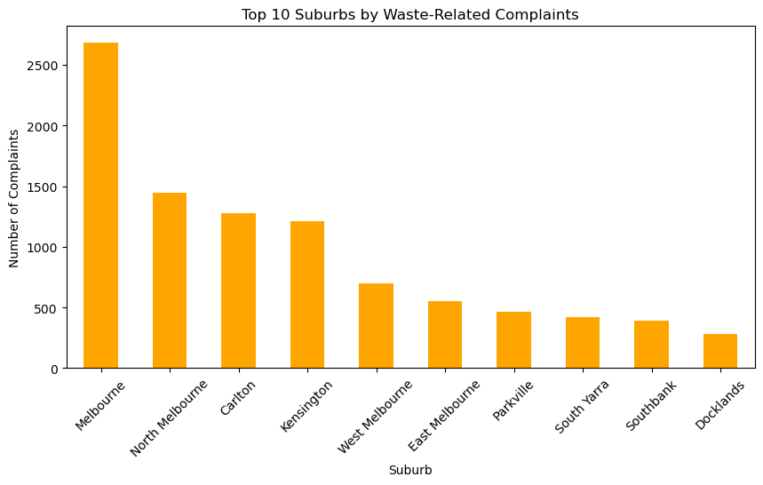

```python
top_suburbs = df_complaints['suburb'].value_counts().head(10)

top_suburbs.plot(kind='bar', color='orange', figsize=(10,5))
plt.title('Top 10 Suburbs by Waste-Related Complaints')
plt.xlabel('Suburb')
plt.ylabel('Number of Complaints')
plt.xticks(rotation=45)
plt.show()
```

#### What the results show

- Clear concentration: Melbourne has the highest complaint volume in your data window, followed by North Melbourne, Carlton, and Kensington.
- The mid-tier includes West Melbourne and East Melbourne, with Parkville, South Yarra, Southbank, and Docklands forming a smaller tail.
- This ranking highlights where operational effort will have the biggest impact if you are prioritizing by total volume.

#### Conclusion

The chart identifies the main hotspots by raw complaint counts, led by Melbourne and North Melbourne, then Carlton and Kensington. Use this list to target short-term actions such as extra crews, route checks, and QA in the top suburbs. As a next step, consider adding a rate view (complaints per 10,000 residents) and overlaying average resolution days to balance workload with service speed.

### Average Social Indicator Results by Topic (City of Melbourne) — Horizontal Bar Chart

#### Why this visualisation

A horizontal bar chart is ideal for ranking many categories with long labels. It lets us compare average percentages across social topics at a glance and quickly spot the highest and lowest scoring areas.

#### What the code does

It groups the social indicators table by topic, computes the mean of the result column, sorts the topics by their averages, and draws a horizontal bar chart. Axis labels, a title, and a light grid are added for readability.

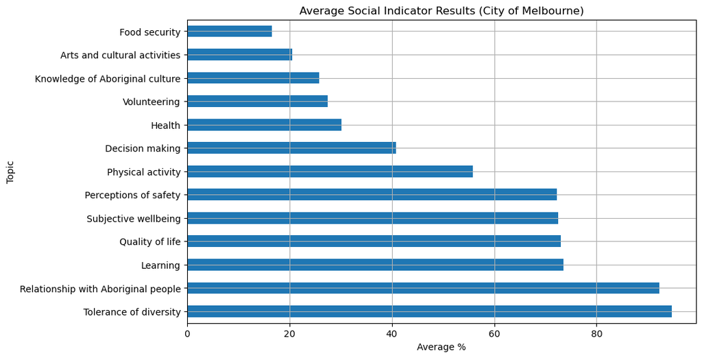

```python
# Group and get average result per topic
health_summary = df_social.groupby('topic')['result'].mean().sort_values(ascending=False)

health_summary.plot(kind='barh', figsize=(10,6))
plt.title('Average Social Indicator Results (City of Melbourne)')
plt.xlabel('Average %')
plt.ylabel('Topic')
plt.grid(True)
plt.show()
```

#### Conclusion

The city scores very well on inclusion and diversity, and broadly positive on life quality and safety. The lowest averages point to practical focus areas: food security, cultural participation, knowledge of Aboriginal culture, volunteering, and basic health indicators. These topics can guide community programs and partnerships, while Physical activity and decision making merit targeted campaigns to lift engagement and outcomes.

### Waste Volume vs Waste-Related Complaints Over Time (Dual-axis line chart)

#### Why this visualisation

Two synchronized lines let us compare how complaints and waste change month by month on the same timeline. A second y-axis makes it possible to see both series clearly even though they use different units.

#### What the code does

It aggregates complaints per month and builds a monthly waste total by summing selected streams (residential, dumped_rubbish, public_litter_bins). The two monthly series are joined into one table and plotted together, using a secondary y-axis for waste.

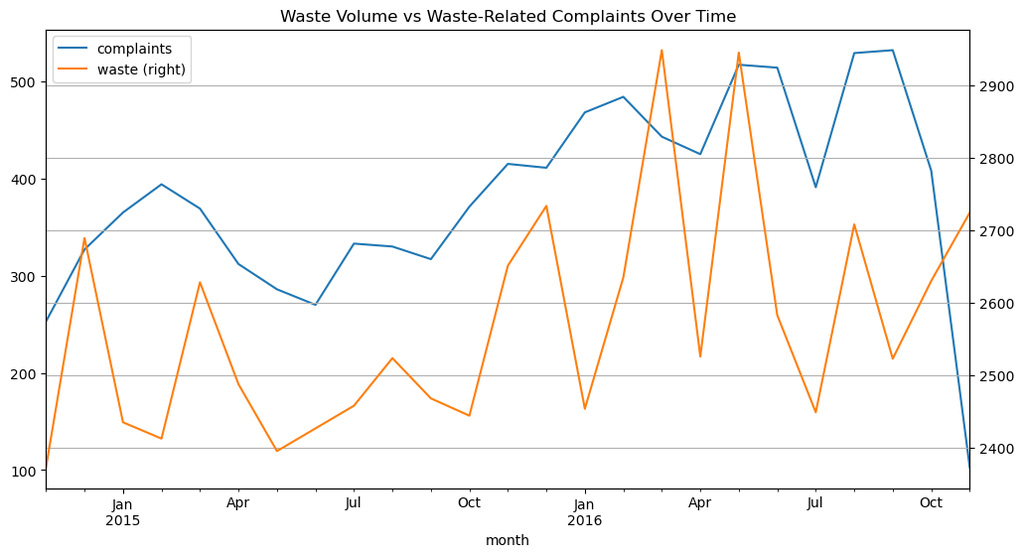

```python
# Complaints per month
df_complaints['month'] = df_complaints['date_received'].dt.to_period('M').dt.to_timestamp()
monthly_complaints = df_complaints.groupby('month').size()

# Waste per month (total of selected categories)
df_waste['month'] = df_waste['date'].dt.to_period('M').dt.to_timestamp()
df_waste['total_waste'] = df_waste[['residential', 'dumped_rubbish', 'public_litter_bins']].sum(axis=1)
monthly_waste = df_waste.groupby('month')['total_waste'].sum()

# Combine and plot
combined = pd.DataFrame({'complaints': monthly_complaints, 'waste': monthly_waste}).dropna()

combined.plot(figsize=(12,6), secondary_y='waste')
plt.title('Waste Volume vs Waste-Related Complaints Over Time')
plt.xlabel('Month')
plt.grid(True)
plt.show()
```

#### Conclusion

Complaints track waste over time, so current waste volumes are a practical early signal for next month’s workload. Use this chart to trigger short-term staffing and route adjustments when waste jumps. For clearer decision support, add a 3-month rolling average, annotate obvious events, and consider plotting the full total_waste (all streams) alongside the same-month and next-month complaint lines.

```python
# Check columns, types, and nulls
print(df_social.info())
print(df_social.head())
print(df_social.columns)
```

```
<class 'pandas.core.frame.DataFrame'>
RangeIndex: 594 entries, 0 to 593
Data columns (total 10 columns):
 #   Column            Non-Null Count  Dtype
---  ------            --------------  -----
 0   indicator         594 non-null    object
 1   type              594 non-null    object
 2   topic             594 non-null    object
 3   description       594 non-null    object
 4   response          594 non-null    object
 5   respondent_group  594 non-null    object
 6   year              594 non-null    int64
 7   sample_size       594 non-null    int64
 8   result            594 non-null    float64
 9   format            594 non-null    object
dtypes: float64(1), int64(2), object(7)
memory usage: 46.5+ KB
None
  indicator                    type                         topic  \
0        19                   Other                        Health
1        19                   Other                        Health
2        19                   Other                        Health
3         1  Council Plan Indicator             Physical activity
4       12b  Council Plan Indicator  Arts and cultural activities

                                         description  \
0                                   Vaping behaviour
1                                   Vaping behaviour
2                                   Vaping behaviour
3          Participate in adequate physical activity
4  Participate in arts and cultural activities in...

                                            response  \
0       Reported as vape daliy or vape occassionally
1       Reported as vape daliy or vape occassionally
2       Reported as vape daliy or vape occassionally
3  Yes, 30 minutes or more on 4 or more days per ...
4                          Yes, in the last 3 months

                                  respondent_group  year  sample_size  result  \
0                              East Melbourne 3002  2023           69     5.0
1                                   Parkville 3052  2023           77    17.6
2  South Yarra 3141 / Melbourne/St Kilda Road 3004  2023          137     8.4
3                                      25-34 years  2023          385    45.1
4                                      55-64 years  2023          115    12.6

     format
0  Per cent
1  Per cent
2  Per cent
3  Per cent
4  Per cent
Index(['indicator', 'type', 'topic', 'description', 'response',
       'respondent_group', 'year', 'sample_size', 'result', 'format'],
      dtype='object')
```

```python
print(df_waste.info())
print(df_waste.head())
print(df_waste.columns)
```

```
<class 'pandas.core.frame.DataFrame'>
RangeIndex: 132 entries, 0 to 131
Data columns (total 14 columns):
 #   Column                 Non-Null Count  Dtype
---  ------                 --------------  -----
 0   date                   132 non-null    datetime64[ns]
 1   residential            132 non-null    float64
 2   public_litter_bins     132 non-null    float64
 3   dumped_rubbish         132 non-null    float64
 4   street_sweepings       132 non-null    float64
 5   mattresses             132 non-null    int64
 6   commingled_recycling   132 non-null    float64
 7   cardboard              132 non-null    float64
 8   hardwaste_to_landfill  132 non-null    float64
 9   hardwaste_recovered    132 non-null    float64
 10  hardwaste_total        132 non-null    float64
 11  green_waste            132 non-null    float64
 12  month                  132 non-null    datetime64[ns]
 13  total_waste            132 non-null    float64
dtypes: datetime64[ns](2), float64(11), int64(1)
memory usage: 14.6 KB
None
        date  residential  public_litter_bins  dumped_rubbish  \
0 2018-05-01      2505.84              251.40          219.54
1 2012-01-01      1618.54              333.92          183.56
2 2018-06-01      2289.50              214.82          184.46
3 2015-04-01      1940.78              346.64          200.12
4 2015-05-01      1822.60              344.11          228.42

   street_sweepings  mattresses  commingled_recycling  cardboard  \
0            489.14         521                932.96      70.36
1            485.82         236                542.28     196.56
2            355.14         503                892.74      65.92
3            461.90         321                613.58     171.30
4            541.78         256                553.24     200.78

   hardwaste_to_landfill  hardwaste_recovered  hardwaste_total  green_waste  \
0                  57.60                15.92            73.52        23.08
1                  36.06                 0.00            36.06         4.30
2                  62.84                15.72            78.56         6.42
3                  80.96                 0.00            80.96         3.04
4                  89.12                 0.00            89.12         4.34

       month  total_waste
0 2018-05-01      2976.78
1 2012-01-01      2136.02
2 2018-06-01      2688.78
3 2015-04-01      2487.54
4 2015-05-01      2395.13
Index(['date', 'residential', 'public_litter_bins', 'dumped_rubbish',
       'street_sweepings', 'mattresses', 'commingled_recycling', 'cardboard',
       'hardwaste_to_landfill', 'hardwaste_recovered', 'hardwaste_total',
       'green_waste', 'month', 'total_waste'],
      dtype='object')
```

```python
print(df_complaints.info())
print(df_complaints.head())
print(df_complaints.columns)
```

```
<class 'pandas.core.frame.DataFrame'>
Index: 9567 entries, 67 to 46472
Data columns (total 8 columns):
 #   Column            Non-Null Count  Dtype
---  ------            --------------  -----
 0   request_status    9567 non-null   object
 1   date_received     9567 non-null   datetime64[ns]
 2   date_completed    9447 non-null   datetime64[ns]
 3   suburb            9567 non-null   object
 4   category          9567 non-null   object
 5   service_desc      9567 non-null   object
 6   days_to_complete  9567 non-null   int64
 7   month             9567 non-null   datetime64[ns]
dtypes: datetime64[ns](3), int64(1), object(4)
memory usage: 672.7+ KB
None
    request_status date_received date_completed       suburb  \
67          CLOSED    2016-05-19     2016-05-19    Melbourne
96          CLOSED    2015-08-03     2015-08-05    Melbourne
98          CLOSED    2015-04-09     2015-04-13   Kensington
101         CLOSED    2015-09-15     2015-09-16    Melbourne
102         CLOSED    2015-05-08     2015-05-14  South Yarra

                              category               service_desc  \
67   Waste, Street Cleaning and Litter      Missed Bin Collection
96   Waste, Street Cleaning and Litter               Damaged Bins
98   Waste, Street Cleaning and Litter                Missing Bin
101  Waste, Street Cleaning and Litter   Syringe pick-up services
102  Waste, Street Cleaning and Litter  Waste collection services

     days_to_complete      month
67                  1 2016-05-01
96                  2 2015-08-01
98                  4 2015-04-01
101                 1 2015-09-01
102                 6 2015-05-01
Index(['request_status', 'date_received', 'date_completed', 'suburb',
       'category', 'service_desc', 'days_to_complete', 'month'],
      dtype='object')
```

### Bin Collection Zones — Quick Data Check (info, head, columns)

#### Use of this code (plain language)

- **Understand the table quickly:** show how many rows/columns there are and what each column is called.
- **Check data quality:** see data types and whether any columns have missing values.
- **Preview real rows:** look at the first few records so we know what the values actually look like before analysing or joining.

```python
print(df_zones.info())
print(df_zones.head())
print(df_zones.columns)
```

```
<class 'pandas.core.frame.DataFrame'>
RangeIndex: 6 entries, 0 to 5
Data columns (total 20 columns):
 #   Column        Non-Null Count  Dtype
---  ------        --------------  -----
 0   geo_point_2d  6 non-null      object
 1   geo_shape     6 non-null      object
 2   desc          6 non-null      object
 3   name          6 non-null      object
 4   rec_ok        6 non-null      object
 5   rec_weeks     6 non-null      int64
 6   rub_start     6 non-null      object
 7   rub_ok        6 non-null      object
 8   rub_day       6 non-null      object
 9   info_url      6 non-null      object
 10  rub_notok     6 non-null      object
 11  rec_url       6 non-null      object
 12  rec_name      6 non-null      object
 13  rec_notok     6 non-null      object
 14  rub_name      6 non-null      object
 15  rec_day       6 non-null      object
 16  rub_weeks     6 non-null      int64
 17  rec_start     6 non-null      object
 18  rub_url       6 non-null      object
 19  missed_ph     6 non-null      object
dtypes: int64(2), object(18)
memory usage: 1.1+ KB
None
                              geo_point_2d  \
0     -37.82597212079299, 144.946122910589
1   -37.78888528182715, 144.94807224053946
2   -37.81350068415623, 144.98033118663488
3    -37.79143593526807, 144.9329101787968
4  -37.797770217788965, 144.96108202950762

                                           geo_shape  \
0  {"coordinates": [[[[144.972962214293, -37.8197...
1  {"coordinates": [[[[144.960219332351, -37.7780...
2  {"coordinates": [[[[144.991297895403, -37.8098...
3  {"coordinates": [[[[144.9348836245, -37.794983...
```

[output cut: 54 more lines]

```
2     Friday          1  2015/09/25
3    Tuesday          1  2015/09/22
4  Wednesday          1  2015/09/23

                                             rub_url     missed_ph
0  https://www.melbourne.vic.gov.au/ForResidents/...  03 9658 9658
1  https://www.melbourne.vic.gov.au/ForResidents/...  03 9658 9658
2  https://www.melbourne.vic.gov.au/ForResidents/...  03 9658 9658
3  https://www.melbourne.vic.gov.au/ForResidents/...  03 9658 9658
4  https://www.melbourne.vic.gov.au/ForResidents/...  03 9658 9658
Index(['geo_point_2d', 'geo_shape', 'desc', 'name', 'rec_ok', 'rec_weeks',
       'rub_start', 'rub_ok', 'rub_day', 'info_url', 'rub_notok', 'rec_url',
       'rec_name', 'rec_notok', 'rub_name', 'rec_day', 'rub_weeks',
       'rec_start', 'rub_url', 'missed_ph'],
      dtype='object')
```

#### Conclusion

The zones table is clean, complete, and small, containing schedules, allowed/not-allowed materials, and clickable guidance links for both recycling and rubbish, plus geometry for mapping. It’s ready to be used as a **lookup** (e.g., to label visualisations, build a “What goes in which bin?” panel, or overlay on a map). If you want to analyse performance by zone, you’ll need a way to **link complaints/addresses to these geometries** (spatial join or zone IDs).

Analyse Trends in Waste Collection Over Time

```python
import seaborn as sns
sns.set_context("notebook")
```

# Monthly Waste Collected by Type — Multi-Series Line Chart

#### Why this visualisation?

A multi-series **line chart** lets us compare how key waste streams change over time on the same monthly axis. It makes it easy to see *which streams are largest*, *which are growing or shrinking*, and *when shifts occur*.

#### Dataset & columns used

- `df_waste` (monthly time series): `date` plus stream columns — `residential`, `public_litter_bins`, `dumped_rubbish`, `street_sweepings`, `commingled_recycling`, `green_waste`.

#### Use of the code (what we are trying to achieve)

- **Reshape** the data so each waste stream can be drawn as its own time-series without writing separate plots.
- **Overlay** all selected streams on a single timeline to compare magnitudes, trends, and seasonality side-by-side.
- **Label & organise** the result (title, axis labels, legend placement) so stakeholders can read the chart quickly and unambiguously.

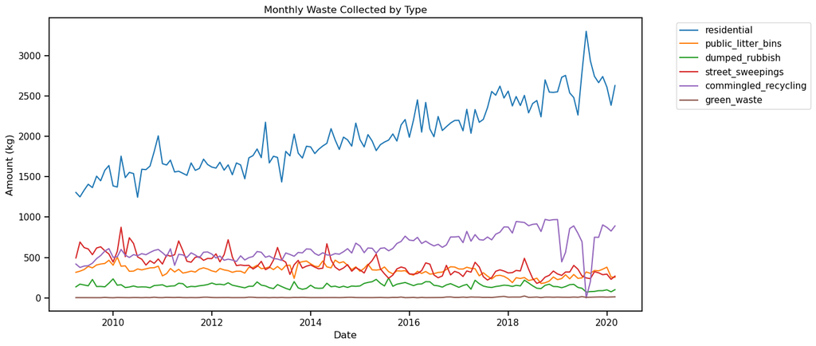

```python
# Sub-categories
cols = ['residential', 'public_litter_bins', 'dumped_rubbish',
        'street_sweepings', 'commingled_recycling', 'green_waste']

df_waste_plot = df_waste.melt(id_vars=["date"], value_vars=cols,
                              var_name="Waste_Type", value_name="Amount")

plt.figure(figsize=(14, 6))
sns.lineplot(data=df_waste_plot, x="date", y="Amount", hue="Waste_Type")
plt.title("Monthly Waste Collected by Type")
plt.xlabel("Date")
plt.ylabel("Amount (kg)")
plt.legend(bbox_to_anchor=(1.05, 1), loc='upper left')
plt.tight_layout()
plt.show()
```

#### Conclusion (from your result)

*Suggested caption:* “Residential drives monthly tonnage and trends upward; commingled recycling grows post-2016, while other streams are comparatively stable.”

# Health Indicator vs Waste Complaints by Suburb

#### Why this visualisation?

A scatter plot lets us test a simple hypothesis: *do places with different health scores also experience different levels of waste complaints?* By putting the **health indicator (%)** on the x-axis and the **number of complaints** on the y-axis, any relationship would show up as a rising (positive) or falling (negative) trend. It’s quick to read, highlights outliers, and is an appropriate first pass before running formal statistics.

#### Datasets & columns

- **Complaints table (`df_complaints`)**: `suburb`, `date_received`/`month`, `days_to_complete`, `category`, etc.
- **Social/Health table (`df_social`)**: `indicator`, `type`, `topic` (Health), `description`, `response`, `respondent_group` (suburb-level groups), `year`, `sample_size`, `result` (percent), `format`.

#### What the code does

It standardises suburb names, aggregates complaint counts per suburb, joins them to the suburb-level health indicator (%) from the social dataset, and plots a scatter; if both variables vary, it also computes a Pearson correlation.  
In your run, the correlation check detected insufficient variation (one variable effectively constant), so only the scatter is displayed.

```python
# Clean suburb names
df_complaints["suburb"] = df_complaints["suburb"].str.upper()
df_social["respondent_group"] = df_social["respondent_group"].str.upper()

# Group complaints
suburb_complaint_counts = df_complaints["suburb"].value_counts().reset_index()
suburb_complaint_counts.columns = ["Suburb", "Complaints"]

# Filter + copy health data
df_health = df_social[df_social["topic"] == "Health"].copy()
df_health["is_suburb"] = df_health["respondent_group"].str.contains(r"\d{4}")
df_suburb_health = df_health[df_health["is_suburb"]].copy()
df_suburb_health.rename(columns={"respondent_group": "Suburb"}, inplace=True)

# Merge
df_health_complaints = pd.merge(df_suburb_health, suburb_complaint_counts, on="Suburb", how="left")
df_health_complaints["Complaints"] = df_health_complaints["Complaints"].fillna(0)

# Check for valid variation
if df_health_complaints["result"].nunique() > 1 and df_health_complaints["Complaints"].nunique() > 1:
    from scipy.stats import pearsonr
    corr, p = pearsonr(df_health_complaints["result"], df_health_complaints["Complaints"])
    print(f"Correlation = {corr:.3f}, p = {p:.4f}")
else:
    print("Correlation not valid: one of the columns has constant values.")
```

```
Correlation not valid: one of the columns has constant values.
```

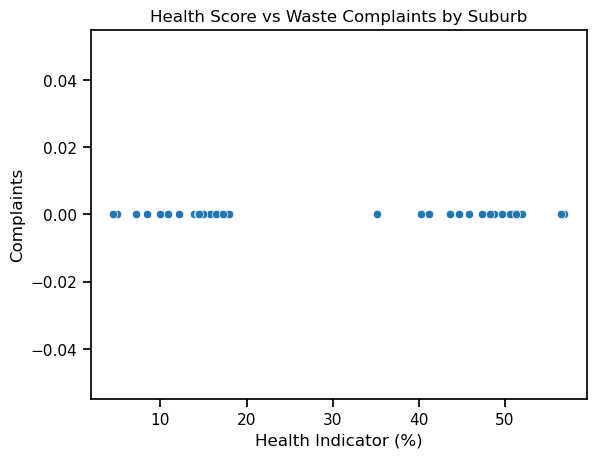

```python
sns.scatterplot(data=df_health_complaints, x="result", y="Complaints")
plt.title("Health Score vs Waste Complaints by Suburb")
plt.xlabel("Health Indicator (%)")
plt.ylabel("Complaints")
plt.show()
```

#### Conclusion from your result

The points sit in a flat band and the correlation test was invalid, indicating **no measurable association** in this joined slice. This is most likely because the merge produced many zero or identical complaint counts (e.g., name mismatches or missing months), or because the chosen health indicator didn’t differ much across suburbs for the filtered year. With the current setup, there is **no evidence** that the selected health indicator and waste complaints are related.

#### Details & assumptions (to make this chart meaningful next time)

- **Key matching:** Ensure suburb keys match on both sides (e.g., strip postcodes from `respondent_group`, standardise case: “MELBOURNE” ⇄ “Melbourne”).
- **Time alignment:** Use the same period for both datasets (e.g., complaints for 2023 vs health `year == 2023`).
- **Metric choice:** Prefer *complaints per 10k residents* over raw counts; use `format == "Per cent"` and select a specific `description/response` (e.g., one health behavior).
- **Sample robustness:** Consider weighting the health percentage by `sample_size` and checking medians/P95s of complaints to reduce outlier influence.

*Short caption:* “No relationship observed between the selected health indicator (%) and waste complaints by suburb in the matched period; result likely driven by low variation or join mismatches.”

# Top 10 Suburbs with Longest Complaint Resolution Times

#### Why this visualisation?

A horizontal bar chart quickly ranks suburbs by **average days to resolve a complaint**. It makes it easy to spot performance outliers and decide where to focus process fixes or extra resourcing.

#### Dataset & columns

- `df_complaints` — one row per request/complaint.
- `suburb`: suburb name (categorical).
- `days_to_complete`: number of days from received to closed (numeric).

#### What the code is doing (in 2–3 lines)

It groups complaints by `suburb`, computes the mean `days_to_complete`, sorts suburbs from slowest to fastest, keeps the top 10, and plots a horizontal bar chart to show the ranking.

1. ```
   avg_days = df_complaints.groupby("suburb")["days_to_complete"].mean().reset_index()
   avg_days.columns = ["Suburb", "Avg_Days"]
   ```

   Aggregates the dataset to one row per suburb with the mean resolution time in days, then renames columns for clarity.

Draws a horizontal bar chart (longer bars = slower). The reversed purple palette visually emphasizes longer delays.

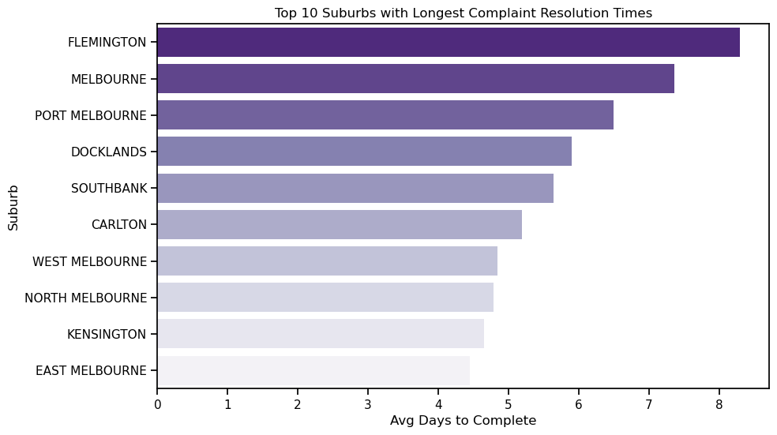

```python
avg_days = df_complaints.groupby("suburb")["days_to_complete"].mean().reset_index()
avg_days.columns = ["Suburb", "Avg_Days"]

top_slow = avg_days.sort_values(by="Avg_Days", ascending=False).head(10)

plt.figure(figsize=(10, 6))
sns.barplot(data=top_slow, x="Avg_Days", y="Suburb", palette="Purples_r")
plt.title("Top 10 Suburbs with Longest Complaint Resolution Times")
plt.xlabel("Avg Days to Complete")
plt.ylabel("Suburb")
plt.show()
```

#### Conclusion

- **Slowest suburbs:** FLEMINGTON (slowest), followed by MELBOURNE and PORT MELBOURNE.
- Next tier includes DOCKLANDS and SOUTHBANK; faster (within this top-10) are CARLTON, WEST MELBOURNE, NORTH MELBOURNE, KENSINGTON, and EAST MELBOURNE.
- **Action:** Prioritise operational review and surge support in the top 3—check staffing, missed-pickup rates, and handoff bottlenecks; use faster suburbs as process benchmarks.